# Using AI to help with code writing

Iryna Schlackow

Student Data Insights, Education Policy Support  
(formerly HERC, NDPH)

2026-09-15

## Talk overview

- Using AI to help with code writing (Sep 2025)
- Using AI to help with code writing (Sep 2026)
- What makes the code well-structured?
- Discussion

[figure not shown]

Acknowledgments to Peter Chetwynd, Craig Smith, Connair Russell-Wilks, our R user group and many others for inspiration and constructive feedback

# Using AI to help with code writing (Sep 2025)

## Context

- Hypothetical higher education institution; linked student-level data
- Comparing performance by student characteristic (e.g. gender) and trying to explain the difference
- Using AI as an interactive coding assistant; query punctuation and spelling preserved
- 15+ years of using R (pre-tidyverse; pre-Stack Overflow)

[figure not shown]

Source: https://oxfordvisit.com/articles/harry-potter-filming-locations-great-hall-christ-church/#google_vignette

## The code that you always forget

how to apply the same operation to several columns in R tidyverse

give me an example of names_pattern argument in pivot_wider in tidyverse

How to construct a regular expression in R containing letter b and not containing letter a

- Short queries;
- excellent concise examples, detailed explanations;
- more useful than Google search due to interactivity;
- helpful suggestions.

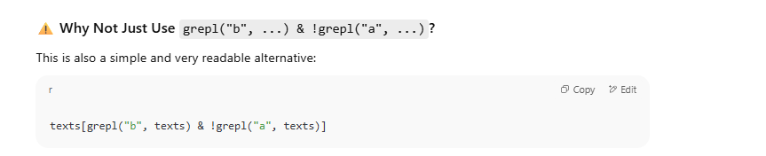

## The code that you want to adapt

Convert this flextable code <…> into kable syntax

Using tidyverse, I want to parameterise this code: <…> I have several columns I want to apply this case_when to

I now want to keep column names and supply variables as a parameter vector

now I want to transpose, have gender on top, variable at the bottom. result is still a data.frame

- most useful when done iteratively and in small incremental steps

## New code/functionality

explain the margin argument in the plot layout command? I am combining two ggplot objects with plotly

kable. I need to left-align heading produced by pack-rows. can I do it with css?

I am writing a quarto revealjs presentation. I need to provide slides in a 16:9 ratio. how can I do this

- Generally good experience, BUT:
- good in producing code that looks plausible; hallucinations with niche requests;
- fine-tuning the query and/or running through several LLMs might help;
- code always needs to be checked.

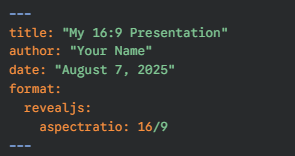

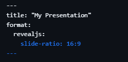

————————————————————————

## Plausible code vs working code

quarto html; how can I generate list of tables & figures?

This is my YAML <…>. Add crossref: true there

error: (line 4, columns 11–15) Field “crossref” has value true, which must instead be ‘false’

but then nothing is produced

i added this but no list was produced

[figure not shown]

Source: https://www.redbubble.com/i/art-board-print/The-Code-Doesn-t-Work-Why-The-Code-Works-Why-funny-programming-meme-by-ProgrammingMeme/65384467.7Q6GI

## Summary: my experience with AI (Sep 2025)

- Generally positive experience; saves time and increases quality
- A non-judgmental tutor available 24/7; polite, (overly) positive and patient. Motivating for learning new things
- Answers are obtained in interactive manner
- The more effort goes into the prompt, there more useful the output. What is it you need?
- Answers need to be checked and understood; hallucinations with less standard questions and long conversation

# Using AI to help with code writing (Sep 2026)

## Same old

- The code that you always forget
- The code that you want to adapt
- New code/functionality
- My baseline knowledge has changed
- My confidence in using AI has changed

## Using AI as a code reviewer

I will post code files here. Please check for obvious errors. Do not re-write, give a bullet list of suggestions.

Check for obvious improvements

Check against the tidyverse style guide

- No feel for an elegant/simple answer; no understanding of the context;
- good for spotting style inconsistencies and simple errors;
- good for making suggestions on how to structure the code.

# What makes the code well-structured?

## Disclaimer

- chatGPT was used in producing the following content but I checked and agreed with the findings
- The examples are based on my code (and my opinion)
- All code is in R, but applicable to other languages
- Code is presented for illustrative purposes and might not be executable

[figure not shown]

Source: https://programmerhumor.io/programming-memes/when-your-code-works-on-the-first-try/

## Ten tips for clean, well-organised statistical code

1. Organise code into clear sections
2. Use meaningful names
3. Keep each step simple
4. Comment the *why*, not the obvious
5. Keep important choices explicit
6. Run code in logical chunks
7. Check results as you go
8. Don’t overwrite raw data
9. Avoid unnecessary repetition
10. Use a master file to make the analysis reproducible

## Organise code into clear sections

```r
#####################################################################
### Load libraries and files ----
#####################################################################

library(tidyverse)
library(ggiraph)

### parameters ----

subject_str <- "biology"

### directories and filenames ----

project_dir <- "//connect.ox.ac.uk/ADMN/AcademicPolicy/Student Data Insights/Projects/Awarding gaps/MPLS"
data_dir <- file.path(project_dir, "data/processed")
output_dir <- file.path(project_dir, "output", subject_str)

### load data ----

df <- read_rds(file.path(data_dir, str_c("df_", subject_str, ".rds")))

#####################################################################
### Data preparation and parameters ----
#####################################################################

### prepare the datasets ----

y0 <- 2019
y1 <- 2024

# filter out the correct year
df <- df %>%
  filter(ucas_cycle >= y0 & ucas_cycle <= y1)

# separate out those who left after 3rd year & stayed on until 4th year
df3 <- df %>%
  filter(exited)
df4 <- df %>%
  filter(!exited)

#####################################################################
### Graphical parameters ----
#####################################################################

colour_m <- "#4285f4"  # Google blue
colour_f <- "#ea4335"  # Google red

#####################################################################
### Data distribution: density and quantiles ----
#####################################################################

# common parameters
var_gender <- "gender"
var_subgroup_p <- "fee_2l"
var_subgroup_t <- "fee_2l"

# input list
param_list <- list(
  # average FPE grade
  list(fpe_or_fhs = "fpe", var_outcome = "result_mean_fpe", xlab_str = "Average FPE grade", filename_prefix = "average fpe grade"),
  # average FHS grade
  list(fpe_or_fhs = "fhs", var_outcome = "result_mean_fhs", xlab_str = "Average FHS grade", filename_prefix = "average fhs grade")
)

# run the wrapper
for (param in param_list) {

  # read off parameters
  var_outcome <- param$var_outcome
  xlab_str <- param$xlab_str
  filename_prefix <- param$filename_prefix
  fpe_or_fhs <- param$fpe_or_fhs

  # read off correct dataset
  df_temp <- if (fpe_or_fhs == "fpe") df else df4

  # run the wrapper
  .data_distribution_wrapper(df = df_temp,
                             var_gender = var_gender, var_subgroup_p = var_subgroup_p, var_subgroup_t = var_subgroup_t, var_outcome = var_outcome,
                             xlab_str = xlab_str,
                             output_dir = output_dir, filename_prefix = filename_prefix, subject_str = subject_str)

  # run the wrapper: UK only
  .data_distribution_wrapper(df = df_temp %>% filter(!!sym(var_subgroup_p) == "UK"),
                             var_gender = var_gender, var_subgroup_p = var_subgroup_p, var_subgroup_t = var_subgroup_t, var_outcome = var_outcome,
                             xlab_str = xlab_str,
                             output_dir = output_dir, filename_prefix = str_c(filename_prefix, " (UK)"), subject_str = subject_str,
                             generate_p_subgroup = FALSE, generate_t = FALSE)
}
```

## Use meaningful names

```r
opportunity_oxford_eligibility

shortlisted_val

state_school_flag

alevel_further_maths

college_1_subject_1_interview_1_score

mat_score_num

mat_score_num_z

disability_group_fpe

temp

alpha

beta

gamma
```

## Comment the *why*, not the obvious

```r
# NB: interview scores only available from 2018
# Further, scale has changed since 2020
# so can only use 2020-2025
# take out 2025 as no ethnicity information

y0 <- 2020
y1 <- 2024

# filter out the correct year
df <- df %>%
  filter(ucas_cycle >= y0 & ucas_cycle <= y1)
```

## Comment the *why*, not the obvious

```r
############################################################
### Run the wrapper and check everything is okay
############################################################

### wrapper output ----

alpha <- .data_prep_wrapper(df_ptes = df_ptes, df_domains = df_domains, df_mad = df_mad)

### check output ----

names(alpha)
nrow(alpha$df)

# which columns were removed in the initial tidy-up
# should be irrelevant columns, not to be presented in the dashboard
alpha$colnames_removed

# questions without an associated domain
# these questions will be removed from the final output
alpha$questions_without_domain

# once NAs are removed, is every username in MAD unique?
# should be TRUE
alpha$mad_id_uniqueness_flag

# is the value column in MAD (eg Distinct Students FHI) always equal to 1?
# should be 0; we are looking for deviations from the rule
alpha$n_mad_last_column

# does every username from PTES appear in MAD?
# should be numeric 0
alpha$n_ptes_mad_id_merged
```

## Keep important choices explicit

```r
#####################################################################
### Load libraries and files ----
#####################################################################

library(tidyverse)
library(ggiraph)

### parameters ----

subject_str <- "biology"

### directories and filenames ----

project_dir <- "//connect.ox.ac.uk/ADMN/AcademicPolicy/Student Data Insights/Projects/Awarding gaps/MPLS"
data_dir <- file.path(project_dir, "data/processed")
output_dir <- file.path(project_dir, "output", subject_str)

### load data ----

df <- read_rds(file.path(data_dir, str_c("df_", subject_str, ".rds")))
```

## Check results as you go

```r
# A* in maths, further maths or physics
head(df_alevels_achieved)
temp <- df_alevels_achieved %>%
  mutate(astar_req = astar * (alevel_maths + alevel_physics + alevel_further_maths))
table(temp$astar_req, exclude = NULL)
table(temp$astar, temp$astar_req, exclude = NULL)

# A*A*A
temp <- temp %>%
  group_by(app_no) %>%
  summarise(astar_req = sum(astar_req),
            astar = sum(astar),
            a_astar = sum(a_astar),
            alevel_maths = sum(alevel_maths + alevel_further_maths),
            alevel_physics = sum(alevel_physics)) %>%
  mutate(offer_met = astar_req >= 2 & astar >= 2 & a_astar >= 3 & alevel_maths >= 1 & alevel_physics >= 1)
head(temp)

### check ----

table(temp$astar, exclude = NULL)
table(temp$a_astar, exclude = NULL)
table(temp$astar_req, exclude = NULL)
table(temp$offer_met, exclude = NULL)
table(temp$offer_met, temp$astar, exclude = NULL)
table(temp$offer_met, temp$a_astar, exclude = NULL)
table(temp$offer_met, temp$alevel_maths, exclude = NULL)
table(temp$offer_met, temp$alevel_physics, exclude = NULL)

nrow(df)
df <- left_join(df, temp %>% select(app_no, offer_met))
nrow(df)

table(df$offer_met, exclude = NULL)
table(df$offer_met, df$homeeuos, exclude = NULL)

# NA
id_temp <- df %>%
  filter(fee_2l == "UK") %>%
  filter(is.na(offer_met)) %>%
  sample_n(10) %>%
  select(app_no) %>%
  pull()
id_temp
for (id_temp_temp in id_temp) {
  print("***")
  print(id_temp_temp)
  print(df_alevels_achieved %>%
          filter(app_no %in% id_temp_temp) %>%
          select(subject, grade))
}
# all good; no A-level data

# TRUE
id_temp <- df %>%
  filter(offer_met) %>%
  sample_n(10) %>%
  select(app_no) %>%
  pull()
id_temp
for (id_temp_temp in id_temp) {
  print("***")
  print(id_temp_temp)
  print(df_alevels_achieved %>%
          filter(app_no %in% id_temp_temp) %>%
          select(subject, grade))
}
# all good

# FALSE
id_temp <- df %>%
  filter(!offer_met) %>%
  sample_n(10) %>%
  select(app_no) %>%
  pull()
id_temp
for (id_temp_temp in id_temp) {
  print("***")
  print(id_temp_temp)
  print(df_alevels_achieved %>%
          filter(app_no %in% id_temp_temp) %>%
          select(subject, grade))
}
# all good; a mixture of those who didn't make A*A*A and those who did but with A* in a wrong subject
```

## Avoid unnecessary repetition: loops

```r
var_list <- c(
  "bme_flag",
  "flag_comb_num",
  "state_school_flag",
  "alevel_chemistry",
  "alevel_physics",
  "alevel_maths"
)

for (var_temp in var_list) {

  print(var_temp)

  print(
    table(temp[[var_temp]], exclude = NULL)
  )
}
```

## Avoid unnecessary repetition: functions

```r
utility_calc <- function(mob, selfc, usualact, pain, anx) {

  # Constant term applied whenever patient has problem in any of the five domains
  # ie at least one of the answers is >1
  constant <- -0.081 * ((mob + selfc + usualact + pain + anx) > 5)

  # Apply decrements to utility (tariff weights) to apply for each domain
  mob_decr <- -0.069 * (mob == 2) - 0.314 * (mob == 3)
  selfc_decr <- -0.104 * (selfc == 2) - 0.214 * (selfc == 3)
  usualact_decr <- -0.036 * (usualact == 2) - 0.094 * (usualact == 3)
  pain_decr <- -0.123 * (pain == 2) - 0.386 * (pain == 3)
  anx_decr <- -0.071 * (anx == 2) - 0.236 * (anx==3)

  # constant term applied if any domain rated 3
  n3 <- -0.269 * (mob == 3 | selfc == 3 | usualact == 3 | pain == 3 | anx == 3)

  # utility score
  score <- 1 + constant + mob_decr + selfc_decr + usualact_decr + pain_decr + anx_decr + n3

  # return value: utility score
  return(score)
}


utility_calc(mob = 1, selfc = 1, usualact = 1, pain = 1, anx = 1)
utility_calc(mob = 3, selfc = 2, usualact = 1, pain = 1, anx = 1)
```

## Avoid unnecessary repetition: tips

- If you see a repetition, ask whether it can be parameterised;
- parameterising reduces errors due to copy-pasting;
- any changes only need to be implemented once;
- use simple structures; nest if necessary;
- ask AI what can be parameterised and how!

## Use a master file to make the analysis reproducible

```r
### example run_all.R file ----

source("1_raw_to_r.R")
source("2_data_prep_all.R")
source("3_data_extraction_biology.R")
source("4_analysis_biology.R")
source("checks_biology.R")
```

Other possible files:

- 4_0_analysis_biology_preamble.R
- functions_biology.R
- functions_global.R

## Top-10 tidyverse stylistic suggestions

1. Use meaningful `snake_case` names
2. Use spaces consistently
3. Break long lines of code
4. Indent to show structure
5. Use blank lines to separate ideas
6. Comment decisions and context
7. Organise scripts into clear sections
8. Use descriptive file names
9. Use `<-` for assignment and `TRUE` / `FALSE`
10. Keep pipes simple and readable

## So, is my code any good?

### 🟢 Strong

- Clear sections
- Meaningful variable names
- Comments that explain decisions
- Important settings made explicit
- Checks throughout the analysis
- Functions and loops reduce repetition
- Raw and processed data kept separate
- Reproducible project structure

### 🟡 Could be better

- Intermediate objects often called `temp`, `alpha`, `beta`, `gamma`
- Some very long lines and pipelines
- Some comments explain what, rather than why
- A few filenames are less descriptive / less Tidyverse-style

## How can AI help with writing good code?

- review your code against a set of rules ;
- generate the set of rules for code review;
- suggest ways to simplify or structure the code;
- generate example datasets, heavily commented code and teaching examples;
- generate reports with Quarto, create code libraries, do vibe coding …
- But you still need to read, understand and check the code!

[figure not shown]

Source: https://x.com/csgeek/status/1465684368412786692

## What am I NOT using AI for?

- Understanding the data and making decisions;
- writing code / text / presentations from scratch;
- vibe coding (not yet anyway…);
- loading identifiable-level data;
- creating memes.

Create a funny meme about chatGPT not having a sense a humour

[figure not shown]

## Summary: good coding habits

1. Clear sections make the structure visible
2. Meaningful names give context
3. Simple steps make problems easier to isolate
4. Comments explain the reasoning
5. Important settings are easy to find
6. Run code in small, testable chunks
7. Check results — not just whether the code runs
8. Keep raw data safe
9. Use functions and loops instead of unnecessary repetition
10. Keep the whole workflow reproducible

The habits are independent of AI. But AI can help with them.

## Thank you!

[figure not shown]

GIF from https://media.giphy.com/media/13HgwGsXF0aiGY/giphy.gif

iryna.schlackow@admin.ox.ac.uk